# Machine Learning Course Project Final

#### Introduction and Background

Using devices such as Jawbone Up, Nike FuelBand, and Fitbit it is now possible to collect a large amount of data about personal activity relatively inexpensively. These type of devices are part of the quantified self movement - a group of enthusiasts who take measurements about themselves regularly to improve their health, to find patterns in their behavior, or because they are tech geeks. One thing that people regularly do is quantify how much of a particular activity they do, but they rarely quantify how well they do it. In this project, your goal will be to use data from accelerometers on the belt, forearm, arm, and dumbell of 6 participants. They were asked to perform barbell lifts correctly and incorrectly in 5 different ways. More information is available from the website here: http://groupware.les.inf.puc-rio.br/har (see the section on the Weight Lifting Exercise Dataset).

#### Goal

The goal of your project is to predict the manner in which they did the exercise. This is the “classe” variable in the training set. You may use any of the other variables to predict with. You should create a report describing how you built your model, how you used cross validation, what you think the expected out of sample error is, and why you made the choices you did. You will also use your prediction model to predict 20 different test cases.

#### Training Dataset Link

The training data for this project are available here: https://d396qusza40orc.cloudfront.net/predmachlearn/pml-training.csv

#### Testing Dataset Link

https://d396qusza40orc.cloudfront.net/predmachlearn/pml-testing.csv

#### Data Loading and Cleaning

First load all the packages that we would need to analyse the data and to build a model to predict the test data.

```r
library(caret)
library(rpart)
library(randomForest)
```

```r
library(rpart.plot)
library(rattle)
library(gbm)
library(survival)
set.seed(12345)
setwd("C:/Users/nvarshney/Desktop/R programming/Coursera/Git Hub and Programming assignments/Course 8/Course Project")
# Load and read the training and test data into R using, read.csv function
training  <- read.csv("pml-training.csv", na.strings = c("NA","#DIV/0!",""))
# Keep this testing data aside for prediction
testing20<- read.csv("pml-testing.csv", na.strings = c("NA","DIV/0!",""))
dim(training)
```

```
## [1] 19622   160
```

```r
dim(testing20)
```

```
## [1]  20 160
```

```r
str(training)
```

```
## 'data.frame':    19622 obs. of  160 variables:
##  $ X                       : int  1 2 3 4 5 6 7 8 9 10 ...
##  $ user_name               : Factor w/ 6 levels "adelmo","carlitos",..: 2 2 2 2 2 2 2 2 2 2 ...
##  $ raw_timestamp_part_1    : int  1323084231 1323084231 1323084231 1323084232 1323084232 1323084232 1323084232 1323084232 1323084232 1323084232 ...
##  $ raw_timestamp_part_2    : int  788290 808298 820366 120339 196328 304277 368296 440390 484323 484434 ...
##  $ cvtd_timestamp          : Factor w/ 20 levels "02/12/2011 13:32",..: 9 9 9 9 9 9 9 9 9 9 ...
##  $ new_window              : Factor w/ 2 levels "no","yes": 1 1 1 1 1 1 1 1 1 1 ...
##  $ num_window              : int  11 11 11 12 12 12 12 12 12 12 ...
##  $ roll_belt               : num  1.41 1.41 1.42 1.48 1.48 1.45 1.42 1.42 1.43 1.45 ...
##  $ pitch_belt              : num  8.07 8.07 8.07 8.05 8.07 8.06 8.09 8.13 8.16 8.17 ...
##  $ yaw_belt                : num  -94.4 -94.4 -94.4 -94.4 -94.4 -94.4 -94.4 -94.4 -94.4 -94.4 ...
##  $ total_accel_belt        : int  3 3 3 3 3 3 3 3 3 3 ...
##  $ kurtosis_roll_belt      : num  NA NA NA NA NA NA NA NA NA NA ...
##  $ kurtosis_picth_belt     : num  NA NA NA NA NA NA NA NA NA NA ...
##  $ kurtosis_yaw_belt       : logi  NA NA NA NA NA NA ...
```

[output cut: 86 more lines]

```r
# As we can see in this dataset there are so many NAs value. First I will remove all the NAs from the data and willcheck for near zero variance column.
```

#### Training Set

Clean variables with more than 75% NAs

```r
mytrain_NA <- training
for (i in 1:length(training)) {
  if (sum(is.na(training[ , i])) / nrow(training) >= .75) {
    for (j in 1:length(mytrain_NA)) {
      if (length(grep(names(training[i]), names(mytrain_NA)[j]))==1) {
        mytrain_NA <- mytrain_NA[ , -j]
      }
    }
  }
}

dim(mytrain_NA)
```

```
## [1] 19622    60
```

```r
names(mytrain_NA)
```

```
##  [1] "X"                    "user_name"            "raw_timestamp_part_1"
##  [4] "raw_timestamp_part_2" "cvtd_timestamp"       "new_window"
##  [7] "num_window"           "roll_belt"            "pitch_belt"
## [10] "yaw_belt"             "total_accel_belt"     "gyros_belt_x"
## [13] "gyros_belt_y"         "gyros_belt_z"         "accel_belt_x"
## [16] "accel_belt_y"         "accel_belt_z"         "magnet_belt_x"
## [19] "magnet_belt_y"        "magnet_belt_z"        "roll_arm"
## [22] "pitch_arm"            "yaw_arm"              "total_accel_arm"
## [25] "gyros_arm_x"          "gyros_arm_y"          "gyros_arm_z"
## [28] "accel_arm_x"          "accel_arm_y"          "accel_arm_z"
## [31] "magnet_arm_x"         "magnet_arm_y"         "magnet_arm_z"
## [34] "roll_dumbbell"        "pitch_dumbbell"       "yaw_dumbbell"
## [37] "total_accel_dumbbell" "gyros_dumbbell_x"     "gyros_dumbbell_y"
## [40] "gyros_dumbbell_z"     "accel_dumbbell_x"     "accel_dumbbell_y"
## [43] "accel_dumbbell_z"     "magnet_dumbbell_x"    "magnet_dumbbell_y"
## [46] "magnet_dumbbell_z"    "roll_forearm"         "pitch_forearm"
## [49] "yaw_forearm"          "total_accel_forearm"  "gyros_forearm_x"
## [52] "gyros_forearm_y"      "gyros_forearm_z"      "accel_forearm_x"
## [55] "accel_forearm_y"      "accel_forearm_z"      "magnet_forearm_x"
## [58] "magnet_forearm_y"     "magnet_forearm_z"     "classe"
```

#### Remove first few columns they don’t seem like a predictor.

```r
mytrain_NA <- mytrain_NA[,-c(1:7)]
str(mytrain_NA)
```

```
## 'data.frame':    19622 obs. of  53 variables:
##  $ roll_belt           : num  1.41 1.41 1.42 1.48 1.48 1.45 1.42 1.42 1.43 1.45 ...
##  $ pitch_belt          : num  8.07 8.07 8.07 8.05 8.07 8.06 8.09 8.13 8.16 8.17 ...
##  $ yaw_belt            : num  -94.4 -94.4 -94.4 -94.4 -94.4 -94.4 -94.4 -94.4 -94.4 -94.4 ...
##  $ total_accel_belt    : int  3 3 3 3 3 3 3 3 3 3 ...
##  $ gyros_belt_x        : num  0 0.02 0 0.02 0.02 0.02 0.02 0.02 0.02 0.03 ...
##  $ gyros_belt_y        : num  0 0 0 0 0.02 0 0 0 0 0 ...
##  $ gyros_belt_z        : num  -0.02 -0.02 -0.02 -0.03 -0.02 -0.02 -0.02 -0.02 -0.02 0 ...
##  $ accel_belt_x        : int  -21 -22 -20 -22 -21 -21 -22 -22 -20 -21 ...
##  $ accel_belt_y        : int  4 4 5 3 2 4 3 4 2 4 ...
##  $ accel_belt_z        : int  22 22 23 21 24 21 21 21 24 22 ...
##  $ magnet_belt_x       : int  -3 -7 -2 -6 -6 0 -4 -2 1 -3 ...
##  $ magnet_belt_y       : int  599 608 600 604 600 603 599 603 602 609 ...
##  $ magnet_belt_z       : int  -313 -311 -305 -310 -302 -312 -311 -313 -312 -308 ...
##  $ roll_arm            : num  -128 -128 -128 -128 -128 -128 -128 -128 -128 -128 ...
```

[output cut: 39 more lines]

```r
# Changing name to original training data
training <- mytrain_NA
```

#### Remove variables with near zero variance.

```r
nzv <- nearZeroVar(training, saveMetrics = TRUE)
nzv
```

```
##                      freqRatio percentUnique zeroVar   nzv
## roll_belt             1.101904     6.7781062   FALSE FALSE
## pitch_belt            1.036082     9.3772296   FALSE FALSE
## yaw_belt              1.058480     9.9734991   FALSE FALSE
## total_accel_belt      1.063160     0.1477933   FALSE FALSE
## gyros_belt_x          1.058651     0.7134849   FALSE FALSE
## gyros_belt_y          1.144000     0.3516461   FALSE FALSE
## gyros_belt_z          1.066214     0.8612782   FALSE FALSE
## accel_belt_x          1.055412     0.8357966   FALSE FALSE
## accel_belt_y          1.113725     0.7287738   FALSE FALSE
## accel_belt_z          1.078767     1.5237998   FALSE FALSE
## magnet_belt_x         1.090141     1.6664968   FALSE FALSE
## magnet_belt_y         1.099688     1.5187035   FALSE FALSE
## magnet_belt_z         1.006369     2.3290184   FALSE FALSE
## roll_arm             52.338462    13.5256345   FALSE FALSE
## pitch_arm            87.256410    15.7323412   FALSE FALSE
## yaw_arm              33.029126    14.6570176   FALSE FALSE
## total_accel_arm       1.024526     0.3363572   FALSE FALSE
## gyros_arm_x           1.015504     3.2769341   FALSE FALSE
## gyros_arm_y           1.454369     1.9162165   FALSE FALSE
## gyros_arm_z           1.110687     1.2638875   FALSE FALSE
## accel_arm_x           1.017341     3.9598410   FALSE FALSE
## accel_arm_y           1.140187     2.7367241   FALSE FALSE
## accel_arm_z           1.128000     4.0362858   FALSE FALSE
## magnet_arm_x          1.000000     6.8239731   FALSE FALSE
## magnet_arm_y          1.056818     4.4439914   FALSE FALSE
## magnet_arm_z          1.036364     6.4468454   FALSE FALSE
## roll_dumbbell         1.022388    84.2065029   FALSE FALSE
## pitch_dumbbell        2.277372    81.7449801   FALSE FALSE
## yaw_dumbbell          1.132231    83.4828254   FALSE FALSE
## total_accel_dumbbell  1.072634     0.2191418   FALSE FALSE
## gyros_dumbbell_x      1.003268     1.2282132   FALSE FALSE
## gyros_dumbbell_y      1.264957     1.4167771   FALSE FALSE
## gyros_dumbbell_z      1.060100     1.0498420   FALSE FALSE
## accel_dumbbell_x      1.018018     2.1659362   FALSE FALSE
## accel_dumbbell_y      1.053061     2.3748853   FALSE FALSE
## accel_dumbbell_z      1.133333     2.0894914   FALSE FALSE
## magnet_dumbbell_x     1.098266     5.7486495   FALSE FALSE
## magnet_dumbbell_y     1.197740     4.3012945   FALSE FALSE
## magnet_dumbbell_z     1.020833     3.4451126   FALSE FALSE
## roll_forearm         11.589286    11.0895933   FALSE FALSE
## pitch_forearm        65.983051    14.8557741   FALSE FALSE
## yaw_forearm          15.322835    10.1467740   FALSE FALSE
## total_accel_forearm   1.128928     0.3567424   FALSE FALSE
## gyros_forearm_x       1.059273     1.5187035   FALSE FALSE
## gyros_forearm_y       1.036554     3.7763735   FALSE FALSE
## gyros_forearm_z       1.122917     1.5645704   FALSE FALSE
## accel_forearm_x       1.126437     4.0464784   FALSE FALSE
## accel_forearm_y       1.059406     5.1116094   FALSE FALSE
## accel_forearm_z       1.006250     2.9558659   FALSE FALSE
## magnet_forearm_x      1.012346     7.7667924   FALSE FALSE
## magnet_forearm_y      1.246914     9.5403119   FALSE FALSE
## magnet_forearm_z      1.000000     8.5771073   FALSE FALSE
## classe                1.469581     0.0254816   FALSE FALSE
```

```r
# There is no variables near to zero variance, all false none to remove.
dim(training)
```

```
## [1] 19622    53
```

#### Data spiliting

```r
inTrain <- createDataPartition(training$classe, p = .7, list = FALSE)
training <- training[inTrain,]
testing <- training[-inTrain,]
dim(training)
```

```
## [1] 13737    53
```

```r
str(training)
```

```
## 'data.frame':    13737 obs. of  53 variables:
##  $ roll_belt           : num  1.41 1.42 1.48 1.48 1.45 1.42 1.42 1.43 1.42 1.42 ...
##  $ pitch_belt          : num  8.07 8.07 8.05 8.07 8.06 8.09 8.13 8.18 8.2 8.21 ...
##  $ yaw_belt            : num  -94.4 -94.4 -94.4 -94.4 -94.4 -94.4 -94.4 -94.4 -94.4 -94.4 ...
##  $ total_accel_belt    : int  3 3 3 3 3 3 3 3 3 3 ...
##  $ gyros_belt_x        : num  0.02 0 0.02 0.02 0.02 0.02 0.02 0.02 0.02 0.02 ...
##  $ gyros_belt_y        : num  0 0 0 0.02 0 0 0 0 0 0 ...
##  $ gyros_belt_z        : num  -0.02 -0.02 -0.03 -0.02 -0.02 -0.02 -0.02 -0.02 0 -0.02 ...
##  $ accel_belt_x        : int  -22 -20 -22 -21 -21 -22 -22 -22 -22 -22 ...
##  $ accel_belt_y        : int  4 5 3 2 4 3 4 2 4 4 ...
##  $ accel_belt_z        : int  22 23 21 24 21 21 21 23 21 21 ...
##  $ magnet_belt_x       : int  -7 -2 -6 -6 0 -4 -2 -2 -3 -8 ...
##  $ magnet_belt_y       : int  608 600 604 600 603 599 603 602 606 598 ...
##  $ magnet_belt_z       : int  -311 -305 -310 -302 -312 -311 -313 -319 -309 -310 ...
##  $ roll_arm            : num  -128 -128 -128 -128 -128 -128 -128 -128 -128 -128 ...
```

[output cut: 39 more lines]

```r
dim(testing)
```

```
## [1] 4110   53
```

In training dataset we have 13737 observations and 53 variables, and in testing dataset 4110 oservations and 53 variables.

#### Finally Clean the testing20 set, that we will be using to predict 20 test cases.

Remove all the NA variables from thes testing20 data and check for if we have any zero variance variable in the data and get the same numbers of variables as we have in the model.

```r
mytest_NA <- testing20
for (i in 1:length(testing20)) {
  if (sum(is.na(testing20[ , i])) / nrow(testing20) >= .75) {
    for (j in 1:length(mytest_NA)) {
      if (length(grep(names(testing20[i]), names(mytest_NA)[j]))==1) {
        mytest_NA <- mytest_NA[ , -j]
      }
    }
  }
}
dim(mytest_NA)
```

```
## [1] 20 60
```

```r
# Remove first few columns from the testing20data,they don't look like a predictor.
mytest_NA <- mytest_NA[,-c(1:7)]
# change name to original name
testing20 <- mytest_NA
# To check  in the test data if we have any variables to near zero variance. All are False, so no Variables to remove
nzv_test<- nearZeroVar(testing20, saveMetrics = TRUE)
nzv_test
```

```
##                      freqRatio percentUnique zeroVar   nzv
## roll_belt                 1.00            90   FALSE FALSE
## pitch_belt                1.00           100   FALSE FALSE
## yaw_belt                  1.00            90   FALSE FALSE
## total_accel_belt          1.20            45   FALSE FALSE
## gyros_belt_x              1.50            70   FALSE FALSE
## gyros_belt_y              2.25            30   FALSE FALSE
## gyros_belt_z              2.50            65   FALSE FALSE
## accel_belt_x              1.00            85   FALSE FALSE
## accel_belt_y              1.50            75   FALSE FALSE
## accel_belt_z              1.00            85   FALSE FALSE
## magnet_belt_x             1.00           100   FALSE FALSE
## magnet_belt_y             1.50            80   FALSE FALSE
## magnet_belt_z             1.50            80   FALSE FALSE
## roll_arm                  8.00            65   FALSE FALSE
## pitch_arm                 8.00            65   FALSE FALSE
## yaw_arm                   8.00            65   FALSE FALSE
## total_accel_arm           1.00            85   FALSE FALSE
## gyros_arm_x               2.00            95   FALSE FALSE
## gyros_arm_y               2.00            95   FALSE FALSE
## gyros_arm_z               1.00            90   FALSE FALSE
## accel_arm_x               2.00            95   FALSE FALSE
## accel_arm_y               1.00           100   FALSE FALSE
## accel_arm_z               1.00           100   FALSE FALSE
## magnet_arm_x              1.00           100   FALSE FALSE
## magnet_arm_y              2.00            95   FALSE FALSE
## magnet_arm_z              1.00           100   FALSE FALSE
## roll_dumbbell             1.00           100   FALSE FALSE
## pitch_dumbbell            1.00           100   FALSE FALSE
## yaw_dumbbell              1.00           100   FALSE FALSE
## total_accel_dumbbell      2.00            70   FALSE FALSE
## gyros_dumbbell_x          1.00            90   FALSE FALSE
## gyros_dumbbell_y          1.00            80   FALSE FALSE
## gyros_dumbbell_z          4.00            85   FALSE FALSE
## accel_dumbbell_x          1.00           100   FALSE FALSE
## accel_dumbbell_y          3.00            90   FALSE FALSE
## accel_dumbbell_z          2.00            95   FALSE FALSE
## magnet_dumbbell_x         1.00           100   FALSE FALSE
## magnet_dumbbell_y         1.00           100   FALSE FALSE
## magnet_dumbbell_z         2.00            95   FALSE FALSE
## roll_forearm              2.00            95   FALSE FALSE
## pitch_forearm             1.00           100   FALSE FALSE
## yaw_forearm               1.00           100   FALSE FALSE
## total_accel_forearm       1.50            65   FALSE FALSE
## gyros_forearm_x           1.00            90   FALSE FALSE
## gyros_forearm_y           1.00           100   FALSE FALSE
## gyros_forearm_z           1.00           100   FALSE FALSE
## accel_forearm_x           1.00           100   FALSE FALSE
## accel_forearm_y           1.00           100   FALSE FALSE
## accel_forearm_z           1.00           100   FALSE FALSE
## magnet_forearm_x          1.00           100   FALSE FALSE
## magnet_forearm_y          1.00           100   FALSE FALSE
## magnet_forearm_z          1.00           100   FALSE FALSE
## problem_id                1.00           100   FALSE FALSE
```

```r
dim(testing20)
```

```
## [1] 20 53
```

```r
str(testing20)
```

```
## 'data.frame':    20 obs. of  53 variables:
##  $ roll_belt           : num  123 1.02 0.87 125 1.35 -5.92 1.2 0.43 0.93 114 ...
##  $ pitch_belt          : num  27 4.87 1.82 -41.6 3.33 1.59 4.44 4.15 6.72 22.4 ...
##  $ yaw_belt            : num  -4.75 -88.9 -88.5 162 -88.6 -87.7 -87.3 -88.5 -93.7 -13.1 ...
##  $ total_accel_belt    : int  20 4 5 17 3 4 4 4 4 18 ...
##  $ gyros_belt_x        : num  -0.5 -0.06 0.05 0.11 0.03 0.1 -0.06 -0.18 0.1 0.14 ...
##  $ gyros_belt_y        : num  -0.02 -0.02 0.02 0.11 0.02 0.05 0 -0.02 0 0.11 ...
##  $ gyros_belt_z        : num  -0.46 -0.07 0.03 -0.16 0 -0.13 0 -0.03 -0.02 -0.16 ...
##  $ accel_belt_x        : int  -38 -13 1 46 -8 -11 -14 -10 -15 -25 ...
##  $ accel_belt_y        : int  69 11 -1 45 4 -16 2 -2 1 63 ...
##  $ accel_belt_z        : int  -179 39 49 -156 27 38 35 42 32 -158 ...
##  $ magnet_belt_x       : int  -13 43 29 169 33 31 50 39 -6 10 ...
##  $ magnet_belt_y       : int  581 636 631 608 566 638 622 635 600 601 ...
##  $ magnet_belt_z       : int  -382 -309 -312 -304 -418 -291 -315 -305 -302 -330 ...
##  $ roll_arm            : num  40.7 0 0 -109 76.1 0 0 0 -137 -82.4 ...
```

[output cut: 39 more lines]

```r
View(testing20)
```

#### Using Machine Learning Algorithim to build different models for prediction.

We will use Random Forest, Decision Trees, and Generalized Boosted Regression Model and then find out which alogorithim provides the best out-of-sample accuracy.

#### Prediction with Random Forest

```r
set.seed(12345)
modfit1 <- train(classe~.,data = training, method = "rf", preProcess = c("center", "scale"), trControl=trainControl(method = "cv", number = 4))
modfit1
```

```
## Random Forest
##
## 13737 samples
##    52 predictor
##     5 classes: 'A', 'B', 'C', 'D', 'E'
##
## Pre-processing: centered (52), scaled (52)
## Resampling: Cross-Validated (4 fold)
## Summary of sample sizes: 10303, 10304, 10301, 10303
## Resampling results across tuning parameters:
##
##   mtry  Accuracy   Kappa
##    2    0.9906816  0.9882116
##   27    0.9887895  0.9858176
##   52    0.9824559  0.9778042
##
## Accuracy was used to select the optimal model using  the largest value.
## The final value used for the model was mtry = 2.
```

```r
# Cross Validation on my testing data
predR <- predict(modfit1,newdata = testing)
RF <-confusionMatrix(predR, testing$classe)
RF$overall["Accuracy"]
```

```
## Accuracy
##        1
```

#### Prediction with Decision Tree

```r
set.seed(12345)
modfit2 <- rpart(classe ~., data = training, method = "class")
modfit2
```

```
## n= 13737
##
## node), split, n, loss, yval, (yprob)
##       * denotes terminal node
##
##    1) root 13737 9831 A (0.28 0.19 0.17 0.16 0.18)
##      2) roll_belt< 129.5 12512 8649 A (0.31 0.21 0.19 0.18 0.11)
##        4) pitch_forearm< -33.95 1093   10 A (0.99 0.0091 0 0 0) *
##        5) pitch_forearm>=-33.95 11419 8639 A (0.24 0.23 0.21 0.2 0.12)
##         10) magnet_dumbbell_y< 439.5 9671 6951 A (0.28 0.18 0.24 0.19 0.11)
##           20) roll_forearm< 123.5 6025 3582 A (0.41 0.18 0.19 0.17 0.058)
##             40) magnet_dumbbell_z< -27.5 2021  673 A (0.67 0.21 0.011 0.081 0.03)
##               80) roll_forearm>=-136.5 1658  352 A (0.79 0.17 0.011 0.025 0.0054) *
##               81) roll_forearm< -136.5 363  217 B (0.12 0.4 0.0083 0.33 0.14) *
##             41) magnet_dumbbell_z>=-27.5 4004 2906 C (0.27 0.17 0.27 0.21 0.072)
##               82) accel_dumbbell_y>=-40.5 3524 2434 A (0.31 0.18 0.19 0.24 0.082)
##                164) yaw_belt>=169.5 494   55 A (0.89 0.051 0 0.059 0.002) *
##                165) yaw_belt< 169.5 3030 2223 D (0.21 0.21 0.22 0.27 0.095)
##                  330) pitch_belt< -43.15 354   53 B (0.02 0.85 0.062 0.045 0.023) *
##                  331) pitch_belt>=-43.15 2676 1885 D (0.24 0.12 0.24 0.3 0.1)
##                    662) roll_belt>=125.5 617  228 C (0.33 0.032 0.63 0.011 0)
##                     1324) magnet_belt_z< -322.5 171    5 A (0.97 0.0058 0.023 0 0) *
##                     1325) magnet_belt_z>=-322.5 446   61 C (0.078 0.043 0.86 0.016 0) *
##                    663) roll_belt< 125.5 2059 1275 D (0.22 0.15 0.12 0.38 0.14)
##                     1326) accel_dumbbell_z< 24.5 1466  836 D (0.29 0.085 0.17 0.43 0.032)
##                       2652) accel_forearm_x>=-70.5 782  411 A (0.47 0.11 0.15 0.23 0.047) *
##                       2653) accel_forearm_x< -70.5 684  231 D (0.073 0.061 0.19 0.66 0.015) *
##                     1327) accel_dumbbell_z>=24.5 593  361 E (0.037 0.3 0.012 0.26 0.39)
##                       2654) roll_dumbbell< 39.24874 194   53 B (0.036 0.73 0.036 0.093 0.11) *
##                       2655) roll_dumbbell>=39.24874 399  188 E (0.038 0.093 0 0.34 0.53) *
##               83) accel_dumbbell_y< -40.5 480   43 C (0.01 0.05 0.91 0.025 0.0042) *
##           21) roll_forearm>=123.5 3646 2449 C (0.076 0.18 0.33 0.24 0.18)
##             42) magnet_dumbbell_y< 290.5 2127 1089 C (0.092 0.13 0.49 0.15 0.13)
##               84) magnet_forearm_z< -251 164   34 A (0.79 0.061 0 0.043 0.1) *
##               85) magnet_forearm_z>=-251 1963  925 C (0.034 0.14 0.53 0.16 0.13) *
##             43) magnet_dumbbell_y>=290.5 1519  991 D (0.053 0.24 0.1 0.35 0.26)
##               86) accel_forearm_x>=-100.5 977  630 E (0.044 0.3 0.15 0.15 0.36)
##                172) magnet_arm_y>=188.5 385  179 B (0.0078 0.54 0.24 0.094 0.12) *
##                173) magnet_arm_y< 188.5 592  293 E (0.068 0.14 0.093 0.19 0.51) *
##               87) accel_forearm_x< -100.5 542  163 D (0.07 0.13 0.022 0.7 0.083) *
##         11) magnet_dumbbell_y>=439.5 1748  842 B (0.034 0.52 0.045 0.22 0.18)
##           22) total_accel_dumbbell>=5.5 1268  448 B (0.047 0.65 0.062 0.021 0.22)
##             44) roll_belt>=-0.58 1077  257 B (0.056 0.76 0.072 0.024 0.086) *
##             45) roll_belt< -0.58 191    0 E (0 0 0 0 1) *
##           23) total_accel_dumbbell< 5.5 480  122 D (0 0.18 0.0021 0.75 0.073) *
##      3) roll_belt>=129.5 1225   43 E (0.035 0 0 0 0.96) *
```

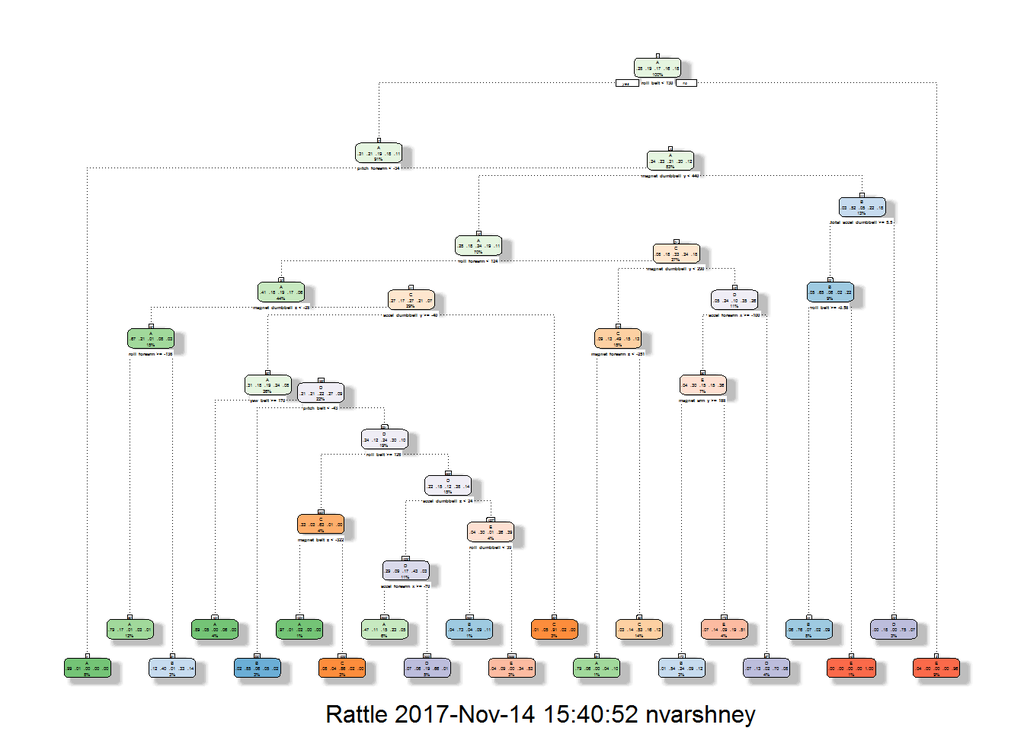

```r
fancyRpartPlot(modfit2)
```

```r
# Cross Validation on my testing data
predD <- predict(modfit2, testing, type = "class")
DT <-confusionMatrix(testing$classe, predD)
DT
```

```
## Confusion Matrix and Statistics
##
##           Reference
## Prediction    A    B    C    D    E
##          A 1047   32   30   27   25
##          B  117  500   90   53   42
##          C   41   63  556   50    9
##          D   77   64   97  382   86
##          E   15   65   84   28  530
##
## Overall Statistics
##
##                Accuracy : 0.7336
##                  95% CI : (0.7198, 0.747)
##     No Information Rate : 0.3156
##     P-Value [Acc > NIR] : < 2.2e-16
##
##                   Kappa : 0.6618
##  Mcnemar's Test P-Value : < 2.2e-16
##
## Statistics by Class:
##
##                      Class: A Class: B Class: C Class: D Class: E
## Sensitivity            0.8072   0.6906   0.6488  0.70741   0.7659
## Specificity            0.9595   0.9108   0.9499  0.90924   0.9438
## Pos Pred Value         0.9018   0.6234   0.7733  0.54108   0.7341
## Neg Pred Value         0.9152   0.9323   0.9112  0.95358   0.9522
## Prevalence             0.3156   0.1762   0.2085  0.13139   0.1684
## Detection Rate         0.2547   0.1217   0.1353  0.09294   0.1290
## Detection Prevalence   0.2825   0.1951   0.1749  0.17178   0.1757
## Balanced Accuracy      0.8834   0.8007   0.7993  0.80833   0.8549
```

```r
DT$overall["Accuracy"]
```

```
##  Accuracy
## 0.7335766
```

#### Prediction with Generalized Boosted Regression

```r
set.seed(12345)
modfit3 <- train(classe ~., data = training, method = "gbm",verbose =  FALSE,trControl=trainControl(method = "cv", number = 4))
modfit3$finalModel
```

```
## A gradient boosted model with multinomial loss function.
## 150 iterations were performed.
## There were 52 predictors of which 42 had non-zero influence.
```

```r
# Cross Validation on my testing data
predG <- predict(modfit3, testing)
GBM <- confusionMatrix(testing$classe, predG)
GBM$overall["Accuracy"]
```

```
##  Accuracy
## 0.9751825
```

#### Model Assessment

```r
AccuracyResults <- data.frame(
Model = c('RF','CART','GBM'),
Accuracy = c(RF$overall[1],DT$overall[1], GBM$overall[1]))
print(AccuracyResults)
```

```
##   Model  Accuracy
## 1    RF 1.0000000
## 2  CART 0.7335766
## 3   GBM 0.9751825
```

#### Final Prediction on the test data with 20 cases

Now we will use the random forest model to predict the outcome variable Classe for the testing dataset.

```r
pred <-predict(modfit1, testing20)
pred
```

```
##  [1] B A B A A E D B A A B C B A E E A B B B
## Levels: A B C D E
```

#### Generating files to submit as answer for the assignment

```r
pml_write_files = function(x){
  n = length(x)
  for(i in 1:n){
    filename = paste0("problem_id_",i,".txt")
    write.table(x[i],file=filename,quote=FALSE,row.names=FALSE,col.names=FALSE)
  }
}

pml_write_files(pred)
```

```r
#Find out how much error we have in Random Forest Model
error <- 1-RF$overll["Accuracy"]
error
```

[output not shown]

```
## numeric(0)
```

#### Conclusion

From the resulting table we can see the Random Forest algorithm yields a better result.

#### Appendices

Just checking the Variable Imporatance in the final Random Forest Model

```r
mod_imp <- varImp(modfit1)
mod_imp
```

```
## rf variable importance
##
##   only 20 most important variables shown (out of 52)
##
##                   Overall
## roll_belt          100.00
## yaw_belt            81.41
## magnet_dumbbell_z   67.49
## pitch_forearm       61.50
## pitch_belt          60.38
## magnet_dumbbell_y   59.50
## magnet_dumbbell_x   50.79
## roll_forearm        49.72
## accel_belt_z        48.89
## magnet_belt_z       46.17
## magnet_belt_y       43.32
## roll_dumbbell       42.89
## accel_dumbbell_y    41.93
## accel_dumbbell_z    37.17
## roll_arm            35.54
## accel_forearm_x     35.31
## accel_dumbbell_x    30.29
## gyros_dumbbell_y    29.92
## gyros_belt_z        28.82
## yaw_dumbbell        28.39
```